# New setup

Published

February 25, 2025

# 1 Hypothesis

We desire to answer the following question:

What is the effect of waiting for test results (to find out target able mutation status and or PDL1 expression) results prior to initiating 1L on the survival of advanced non-small cell lung cancer patients?

There are wo says to answer this question.

1. Simple case: fix the time point which we want to answer. That is, what is the effect of waiting for maximum 3 weeks prior to initiating 1L on survival?
   - Based on the epi textbook:Among persons who initiated 1L before waiting for the test result, what amount of the incidence of death is initiaing 1L immeditaely responsible for? Should anything be done to modify or eliminate immeditaely initiation of 1L?
2. Complex case: let the number of weeks vary and pool the results. That is, in general, what is the effect of waiting for test result prior to initiating 1L on survival?

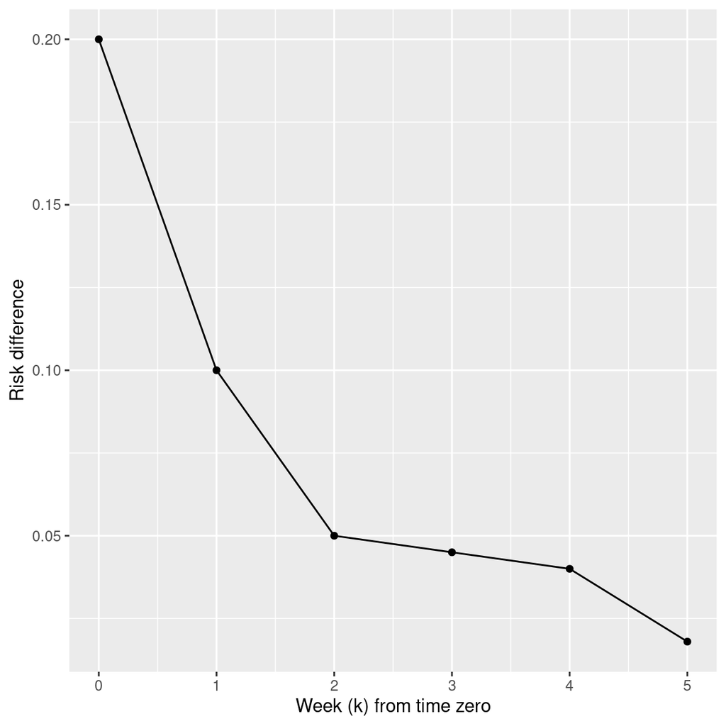

Figure 1: Mock graph of the result

# 2 Set up

$$\begin{align}
k&=\{1,2,...\} \text{, number of weeks from time zero.} \\
A_k &=\begin{cases}
1, & \text{if treatment is initiated prior to minimum of end of week k and valid test result} \\
0, & \text{if treatment is NOT initiated prior to minimum of end of week k and valid test result.}
\end{cases}
\end{align}$$

where the “valid test” is the test result indicating negative or positive for targetable mutations or PD1L expression. This information is provided in the dataset in the “BiomarkerStatus” column. If the column has any one of the following entries, the observation is considered valid.:

Check with Wally if the followings are to be used:

- No interpretation given in report  
- Unsuccessful/indeterminate test - Unknown - Variant of Unknown Significance (VUS) positive - Results pending - Equivocal - Other result type positive - Unknown result type positive - PD-L1 equivocal

- Mutation positive
- PD-L1 positive
- Rearrangement present
- Rearrangement positive
- Amplification positive
- Protein expression positive
- PD-L1 positive
- Mutation negative
- Negative
- PD-L1 negative/not detected
- Rearrangement not present

# 3 Exclusion

Table 1: Exclusion criteria, applied sequentially from top to bottom. Initial sample size is 85,572. The “Diagnosis” outer column header shows the “Number excluded” and “Number remaining” when the time zero is set as advanced diagnosis date. Similarly, the “Biopsy” outer column header shows the same things when the time zero is set at the 1st biopsy on or after advanced diagnosis date.

| **Exclusion** | Diagnosis **Number excluded** | Diagnosis **Number remaining** | Biopsy **Number excluded** | Biopsy **Number remaining** |
| --- | --- | --- | --- | --- |
| Missing time zero | 0 | 85572 | 28489 | 57083 |
| Started 1L therapy before time zero | 999 | 84573 | 2816 | 54267 |
| Observed valid test result before time zero | 7740 | 76833 | 2911 | 51356 |
| Does not have observed event/censoring date | 319 | 76514 | 67 | 51289 |

Table 1 shows show exclusion criteria and sample number when the time zero is set as either advanced diagnosis date or 1st biopsy date $>=$ advanced diagnosis date.

Based on the table, using advanced diagnosis date as time zero results in sample size of 76514, while using 1st biopsy date $>=$ advanced diagnosis date results in sample size of 51289.

# 4 Proportion of patients experiencing important events

In this section, we present cumulative proportion of patients experiencing the following events in each $k$(week):

1. Earliest valid test result
2. Staring 1L therapy
3. Death
4. $A_k$

## 4.1 Cumulative proportion of earliest valid test result

Table 2: Cumulative proportion of earliest valid test

(a) Diagnosis

| **Week (k)** | **Proportion observed valid test**<sup>1</sup> |
| --- | --- |
| 1 | 0.060 |
| 2 | 0.202 |
| 3 | 0.319 |
| 4-5 | >= 0.400 & < 0.500 |
| 6-14 | >= 0.500 & < 0.600 |
| 15-534 | >= 0.600 & < 0.700 |

<sup>1</sup> Maximum proportion of observed valid test is 0.679, with the denominator used to calculate proportion = 76514. The last k which the earliest test result was observed was 534.

(b) Biopsy

| **Week (k)** | **Proportion observed valid test**<sup>1</sup> |
| --- | --- |
| 1 | 0.118 |
| 2 | 0.360 |
| 3 | 0.528 |
| 4 | 0.649 |
| 5-6 | >= 0.700 & < 0.800 |
| 7-51 | >= 0.800 & < 0.900 |
| 52-430 | >= 0.900 & < 1.000 |

<sup>1</sup> Maximum proportion of observed valid test is 0.921, with the denominator used to calculate proportion = 51289. The last k which the earliest test result was observed was 430.

## 4.2 Cumulative proportion of 1L initiation

Table 3: Cumulative proportion of 1L therapy initiation

(a) Diagnosis

| **Week (k)** | **Proportion received 1L**<sup>1</sup> |
| --- | --- |
| 1-2 | >= 0.000 & < 0.100 |
| 3 | 0.158 |
| 4 | 0.257 |
| 5 | 0.348 |
| 6-7 | >= 0.400 & < 0.500 |
| 8-11 | >= 0.500 & < 0.600 |
| 12-73 | >= 0.600 & < 0.700 |
| 74-611 | >= 0.700 & < 0.800 |

<sup>1</sup> Maximum proportion of receiving 1L therapy is 0.730, with the denominator used to calculate proportion = 76514. The last 1L initiation was observed during k = 611.

(b) Biopsy

| **Week (k)** | **Proportion received 1L**<sup>1</sup> |
| --- | --- |
| 1-2 | >= 0.000 & < 0.100 |
| 3 | 0.184 |
| 4 | 0.296 |
| 5 | 0.398 |
| 6 | 0.480 |
| 7-8 | >= 0.500 & < 0.600 |
| 9-17 | >= 0.600 & < 0.700 |
| 18-589 | >= 0.700 & < 0.800 |

<sup>1</sup> Maximum proportion of receiving 1L therapy is 0.784, with the denominator used to calculate proportion = 51289. The last 1L initiation was observed during k = 589.

## 4.3 Cumulative proportion of death

Table 4: Cumulative proportion of death

(a) Diagnosis

| **Week (k)** | **Proportion dead**<sup>1</sup> |
| --- | --- |
| 1-9 | >= 0.000 & < 0.100 |
| 10-17 | >= 0.100 & < 0.200 |
| 18-28 | >= 0.200 & < 0.300 |
| 29-43 | >= 0.300 & < 0.400 |
| 44-67 | >= 0.400 & < 0.500 |
| 68-108 | >= 0.500 & < 0.600 |
| 109-233 | >= 0.600 & < 0.700 |
| 234-620 | >= 0.700 & < 0.800 |

<sup>1</sup> Maximum proportion of death is 0.732, with the denominator used to calculate proportion = 76514. The last death was observed during k = 620.

(b) Biopsy

| **Week (k)** | **Proportion dead**<sup>1</sup> |
| --- | --- |
| 1-9 | >= 0.000 & < 0.100 |
| 10-18 | >= 0.100 & < 0.200 |
| 19-30 | >= 0.200 & < 0.300 |
| 31-47 | >= 0.300 & < 0.400 |
| 48-73 | >= 0.400 & < 0.500 |
| 74-120 | >= 0.500 & < 0.600 |
| 121-339 | >= 0.600 & < 0.700 |
| 340-595 | >= 0.700 & < 0.800 |

<sup>1</sup> Maximum proportion of death is 0.708, with the denominator used to calculate proportion = 51289. The last death was observed during k = 595.

## 4.4 Cumulative proportion of $A_k$

Table 5: Cumulative proportion of A_k

(a) Diagnosis

| **Week (k)** | **Proportion of A_k=1**<sup>1</sup> |
| --- | --- |
| 1 | 0.017 |
| 2 | 0.059 |
| 3 | 0.109 |
| 4-5 | >= 0.150 & < 0.200 |
| 6-7 | >= 0.200 & < 0.250 |
| 8-28 | >= 0.250 & < 0.300 |
| 29-534 | >= 0.300 & < 0.350 |

<sup>1</sup> Maximum proportion of of A_k=1 is 0.325, with the denominator used to calculate proportion = 76514. The last k which the earliest test result was observed was 534.

(b) Biopsy

| **Week (k)** | **Proportion of A_k=1**<sup>1</sup> |
| --- | --- |
| 1 | 0.022 |
| 2-3 | >= 0.050 & < 0.100 |
| 4 | 0.128 |
| 5-17 | >= 0.150 & < 0.200 |
| 18-430 | >= 0.200 & < 0.250 |

<sup>1</sup> Maximum proportion of of A_k=1 is 0.213, with the denominator used to calculate proportion = 51289. The last k which the earliest test result was observed was 430.

## 4.5 Combined table

Table 6: All four cumulative proportions, with shared k value. The time zero is set on the advanced diagnosis date.

| Week (k) | Cumulative Proportion A_k=1<sup>1</sup> | Cumulative Proportion observed valid test<sup>2</sup> | Cumulative Proportion received 1L<sup>3</sup> | Cumulative Proportion dead<sup>4</sup> |
| --- | --- | --- | --- | --- |
| 1 | 0.017 | 0.060 | 0.018 | 0.000 |
| 2 | 0.059 | 0.202 | 0.072 | 0.000 |
| 3 | 0.109 | 0.319 | 0.158 | 0.008 |
| 4 | 0.156 | 0.410 | 0.257 | 0.018 |
| 5 | 0.194 | 0.472 | 0.348 | 0.032 |
| 6-10 | 0.221-0.270 | 0.512-0.579 | 0.423-0.574 | 0.047-0.110 |
| 11-20 | 0.275-0.294 | 0.586-0.614 | 0.590-0.644 | 0.125-0.228 |
| 21-50 | 0.294-0.309 | 0.615-0.643 | 0.647-0.685 | 0.236-0.432 |
| 51-100 | 0.310-0.319 | 0.644-0.663 | 0.686-0.710 | 0.437-0.584 |
| 101-200 | 0.319-0.323 | 0.663-0.675 | 0.710-0.724 | 0.586-0.686 |
| 201-300 | 0.323-0.325 | 0.675-0.678 | 0.724-0.728 | 0.687-0.717 |
| 301-400 | 0.325-0.325 | 0.678-0.679 | 0.728-0.729 | 0.717-0.727 |
| 401-500 | 0.325-0.325 | 0.679-0.679 | 0.729-0.729 | 0.727-0.731 |
| 501-620 | 0.325-0.325 | 0.679-0.679 | 0.729-0.730 | 0.731-0.732 |

<sup>1</sup> Maximum proportion of of A_k=1 is 0.325, with the denominator used to calculate proportion = 76514. The last k which the earliest test result was observed was 534.  
<sup>2</sup> Maximum proportion of observed valid test is 0.679, with the denominator used to calculate proportion = 76514. The last k which the earliest test result was observed was 534.  
<sup>3</sup> Maximum proportion of receiving 1L therapy is 0.730, with the denominator used to calculate proportion = 76514. The last 1L initiation was observed during k = 611.  
<sup>4</sup> Maximum proportion of death is 0.732, with the denominator used to calculate proportion = 76514. The last death was observed during k = 620.

Table 7: All four cumulative proportions, with shared k value. The time zero is set on the 1st biopsy day on or after advanced diagnosis date.

| Week (k) | Cumulative Proportion A_k=1<sup>1</sup> | Cumulative Proportion observed valid test<sup>2</sup> | Cumulative Proportion received 1L<sup>3</sup> | Cumulative Proportion dead<sup>4</sup> |
| --- | --- | --- | --- | --- |
| 1 | 0.022 | 0.118 | 0.025 | 0.001 |
| 2 | 0.058 | 0.360 | 0.085 | 0.002 |
| 3 | 0.097 | 0.528 | 0.184 | 0.009 |
| 4 | 0.128 | 0.649 | 0.296 | 0.018 |
| 5 | 0.151 | 0.725 | 0.398 | 0.031 |
| 6-10 | 0.167-0.192 | 0.772-0.842 | 0.480-0.641 | 0.045-0.106 |
| 11-20 | 0.194-0.201 | 0.849-0.874 | 0.657-0.709 | 0.120-0.218 |
| 21-50 | 0.202-0.207 | 0.876-0.899 | 0.711-0.746 | 0.226-0.413 |
| 51-100 | 0.207-0.210 | 0.900-0.913 | 0.747-0.767 | 0.417-0.564 |
| 101-200 | 0.210-0.212 | 0.913-0.920 | 0.767-0.780 | 0.566-0.667 |
| 201-300 | 0.212-0.212 | 0.920-0.921 | 0.780-0.782 | 0.667-0.695 |
| 301-400 | 0.212-0.213 | 0.921-0.921 | 0.782-0.783 | 0.695-0.704 |
| 401-500 | 0.213-0.213 | 0.921-0.921 | 0.783-0.783 | 0.704-0.707 |

<sup>1</sup> Maximum proportion of of A_k=1 is 0.213, with the denominator used to calculate proportion = 51289. The last k which the earliest test result was observed was 430.  
<sup>2</sup> Maximum proportion of observed valid test is 0.921, with the denominator used to calculate proportion = 51289. The last k which the earliest test result was observed was 430.  
<sup>3</sup> Maximum proportion of receiving 1L therapy is 0.784, with the denominator used to calculate proportion = 51289. The last 1L initiation was observed during k = 589.  
<sup>4</sup> Maximum proportion of death is 0.708, with the denominator used to calculate proportion = 51289. The last death was observed during k = 595.

# 5 Pros and Cons for the two time zeros

Table 8: Pros and cons of using different survival time zero

[output not shown]